# NYC Flights Delay Analysis

Flight performance patterns using `nycflights13` and weather data

Thomas Mason

Will Anan

December 2025

# Executive Summary

This report analyzes **326,074 complete 2013 flight records** from New York City airports and combines them with hourly weather conditions. The goal is to identify the patterns most associated with arrival delays and to present the results in a readable, decision-oriented format.

```
<div class="metric-value">326,074</div>
<div class="metric-label">complete flight records analyzed</div>
```

```
<div class="metric-value">6.9 min</div>
<div class="metric-label">average arrival delay</div>
```

```
<div class="metric-value">23.7%</div>
<div class="metric-label">flights delayed more than 15 minutes</div>
```

```
<div class="metric-value">15.7%</div>
<div class="metric-label">flights delayed more than 30 minutes</div>
```

The strongest result is practical: departure delay explains most of the arrival-delay variation. Weather and carrier differences still matter, but the operational starting point is preventing late departures from compounding into late arrivals.

# Data Preparation

The analysis uses the `flights` and `weather` tables from `nycflights13`. Weather readings were aggregated to one row per hour before merging, which avoids the many-to-many join problem that made the earlier knit output noisy.

| Metric | Value |
| --- | --- |
| Flight records after cleaning | 326,074 |
| Average departure delay | 12.6 minutes |
| Average arrival delay | 6.9 minutes |
| Median arrival delay | -5 minutes |
| Longest arrival delay | 1,272 minutes |
| Carriers represented | 16 |

# Delay Distribution

Most flights arrive close to schedule, but the right tail is long. A small share of flights creates a large amount of passenger disruption.

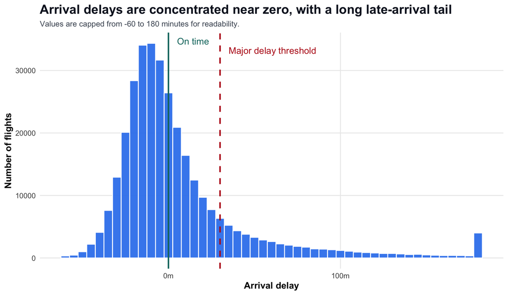

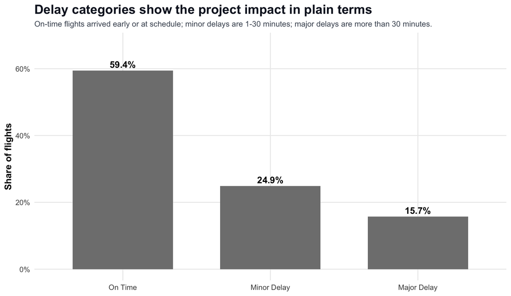

# Regression Results

The regression model explains **88.7%** of arrival-delay variation. Departure delay is the clearest predictor: each additional minute of departure delay corresponds to roughly **1.01 additional minute** of arrival delay, after controlling for distance, air time, weather, and carrier.

| Term | Estimate | p-value |
| --- | --- | --- |
| Departure delay | 1.011 | < 0.001 |
| Air time | 0.771 | < 0.001 |
| Distance | -0.099 | < 0.001 |
| Temperature | 0.158 | < 0.001 |
| Wind speed | 0.172 | < 0.001 |
| Visibility | -1.066 | < 0.001 |

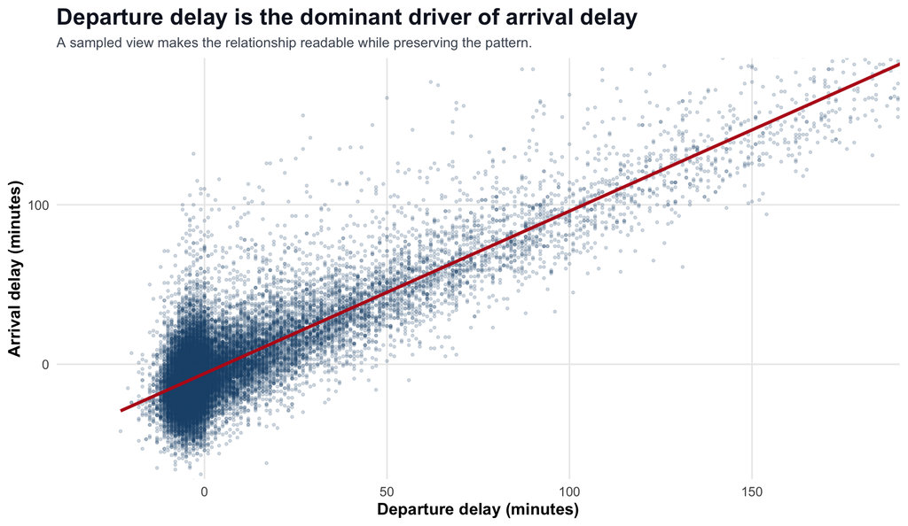

# Carrier Differences

Carrier performance varies after cleaning for complete records. The chart below only includes carriers with at least 1,000 analyzed flights to avoid over-reading very small samples.

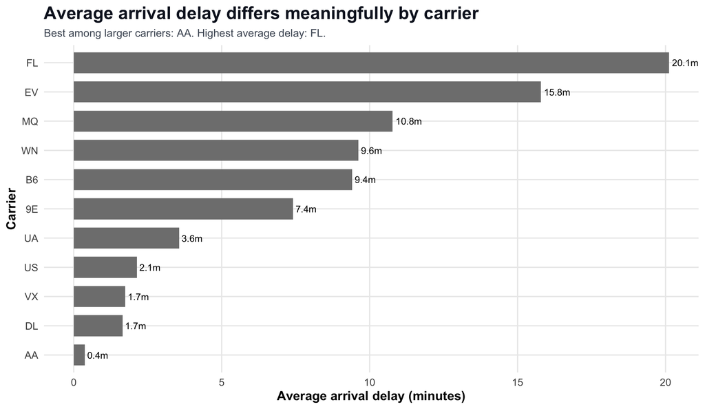

# Monthly and Weather Patterns

Delays are not evenly distributed across the year. Seasonal pressure, airport congestion, and weather disruptions show up in the monthly averages.

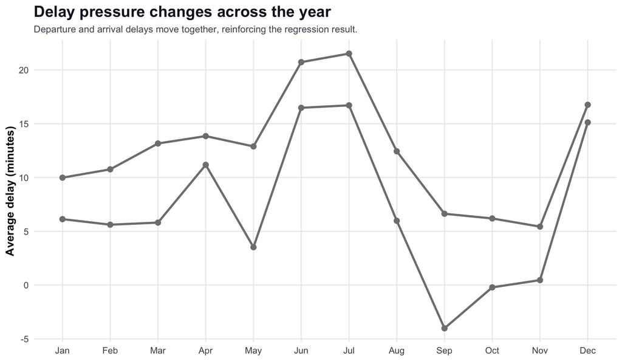

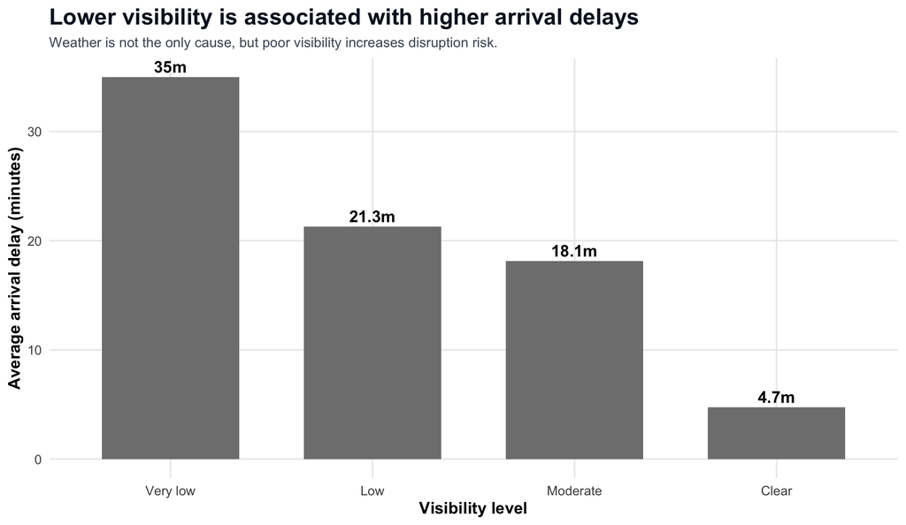

# Clustering Flight Delay Profiles

K-means clustering groups flights into three broad operational profiles based on delay, distance, air time, and weather variables.

[figure not shown]

# Association Rules

Association rule mining was used to identify common relationships between carriers and delay categories. The table reports the strongest rules by lift, which highlights rules that are more distinctive than simple frequency alone.

|  | If | Then | support | confidence | lift |
| --- | --- | --- | --- | --- | --- |
| 6 | {carrier=AA} | {delay_cat=On Time} | 6.5% | 66.5% | 1.12 |
| 1 | {carrier=VX} | {delay_cat=On Time} | 1.0% | 65.9% | 1.11 |
| 7 | {carrier=DL} | {delay_cat=On Time} | 9.6% | 65.6% | 1.10 |
| 4 | {carrier=US} | {delay_cat=On Time} | 3.8% | 62.9% | 1.06 |
| 3 | {carrier=9E} | {delay_cat=On Time} | 3.3% | 61.6% | 1.04 |
| 10 | {carrier=UA} | {delay_cat=On Time} | 10.9% | 61.6% | 1.04 |
| 9 | {carrier=B6} | {delay_cat=On Time} | 9.3% | 56.4% | 0.95 |
| 2 | {carrier=WN} | {delay_cat=On Time} | 2.1% | 56.1% | 0.94 |

# Key Takeaways

1. **Departure delay is the central predictor.** The regression model explains 88.7% of arrival-delay variation, and departure delay carries the strongest practical interpretation.
2. **Carrier differences are visible.** Some carriers have materially higher average arrival delays, suggesting operational differences beyond weather alone.
3. **Weather still matters.** Lower visibility and seasonal conditions increase disruption risk, even if they do not explain as much variation as late departures.
4. **Clusters reveal delay profiles.** Flights naturally separate into on-time, moderately delayed, and heavily delayed groups.

Overall, the analysis suggests that delay reduction should focus first on departure operations, then use carrier, seasonal, and weather-risk patterns for targeted scheduling and passenger communication improvements.